# ASSESSMENT OF THE MEDITERRANEAN SWORDFISH using A4A

SCRS/2020/078

## Introduction

## Introduction

- A4a is a statistical catch-at-age stock assessment model (Jardim et al., 2015)
- Is defined by submodels for F-at-age, abundance indices catchability-at-age, recruitment, observation variance of catch and abundance indices-at-age and population’s age structure in the first year
- Baranov’s equation for the catches is assumed
- lognormal errors for the catch and indices
- Works forward in time
- Implemented in R statistical software - part of the FLR library (Kell et al., 2007)

## Materials and Methods

## Materials and Methods

### Catch Data

- Catch-at-age data since 1985
- plus group 5
- fbar at 2 - 4

### CPUE Data

- Five standardized CPUE series
  - Greek longliners since 1987
  - Moroccan longliners since 2012
  - Spanish longliners since 1988
  - Ligurian longliners since 2010
  - Sicilian longliners from 1991 to 2009
- Representative of age groups 2 - 4

## CPUE indices

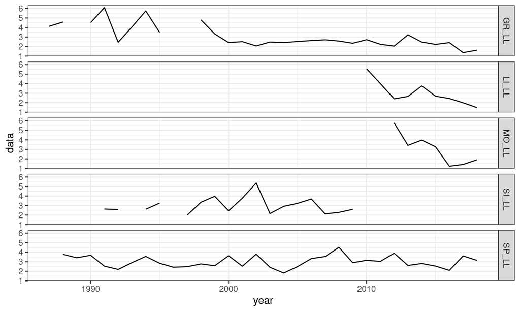

## Candidate Runs

- Many preliminary trials with:
  - Full time series
  - Various assumptions for the different submodels
  - Excluding some of the indices
- Four trials considered:
  - Constant M = 0.2
  - M vector - Lorenzen’s formulation
  - Including estimated Discards and constant M
  - Including estimated Discards and Lorenzen M

## Model setup

**The model setup is the same for all runs**

- Fishing mortality \(\mathbf{F}\) \[F: \quad \sim s(year, k = 17) + s(age, k = 3)\]
- Recruitment \(\mathbf{R}\) \[R:\quad \sim s(year, k = 15)\]
- catchability \(\mathbf{Q}\)

\[ Q : \begin{cases} \sim 1, &\quad \text{Greek longline}\\ \sim 1, &\quad \text{Spanish longline}\\ \sim s(year, k=3), &\quad \text{Moroccan longline}\\ \sim s(year, k=3), &\quad \text{Ligurian longline}\\ \sim 1, &\quad \text{Sicilian longline}\\ \end{cases} \]

## Model setup

- observation variance \(\mathbf{\sigma^2}\) of the catches

\[ \sigma^2 \sim s(age, k = 3)\] - variance of the indices \[ \tau^{2}_{s} \sim 1,\quad \text{for all indices } s\]

- initial age structure \(\mathbf{N_1}\)

\[ N : \quad\sim s(age, k =3)\]

## Results

The results for the four different runs are presented in the following sections. The constant natural mortality M = 0.2, (constant M), the Lorenzen natural mortality (Lorenzen M), the run with discards included and M assumed constant (Discards) and the run with discards included and Lorenzen natural mortality vector (Discards and Lorenzen M).

## candidate run

### assuming constant M

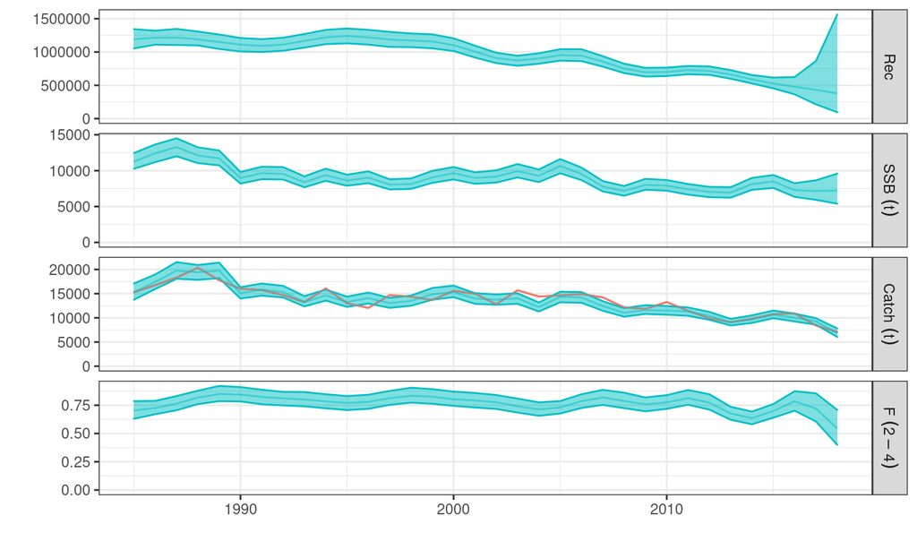

## candidate run

### assuming constant M - harvest

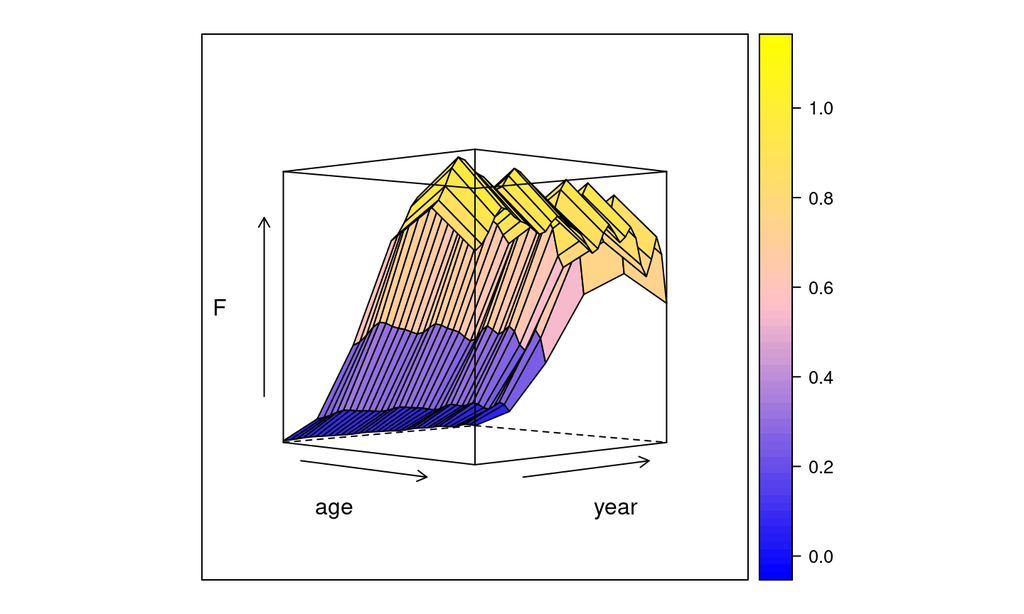

## Diagnostics

### candidate run assuming constant M

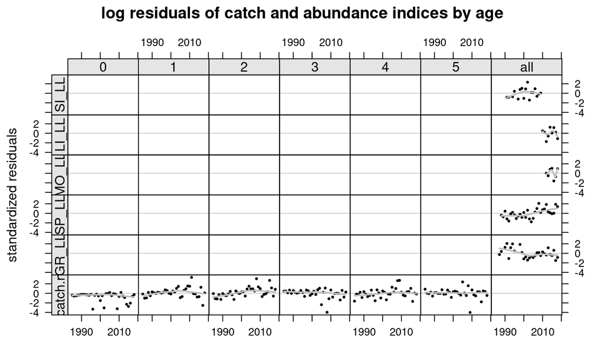

## Diagnostics

### candidate run assuming constant M

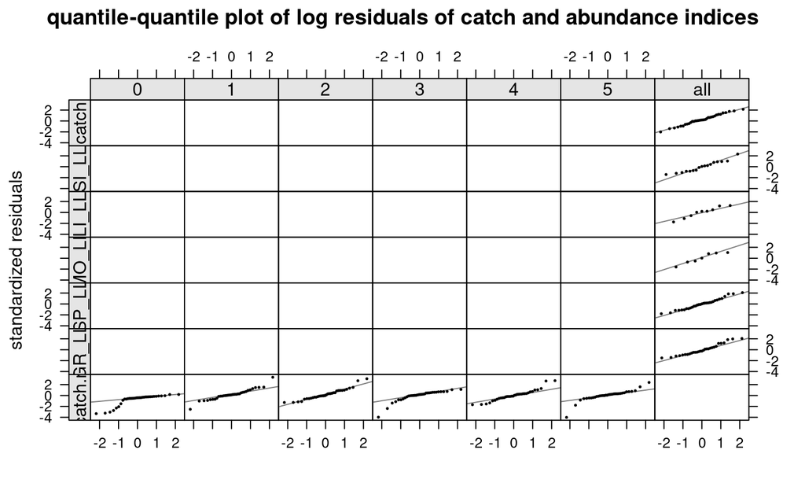

## Diagnostics

### candidate run assuming constant M

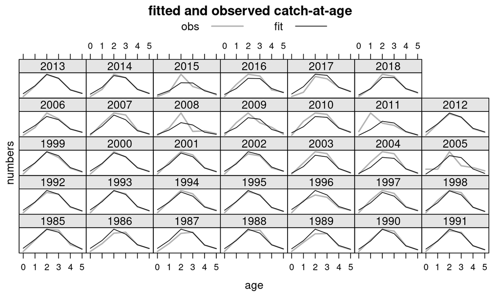

## Retrospective plot

### candidate run assuming constant M

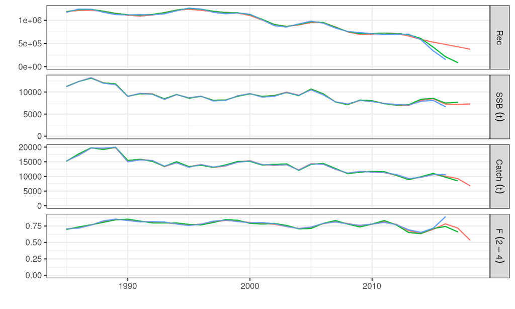

## Candidate run

### assuming Lorenzen M vector

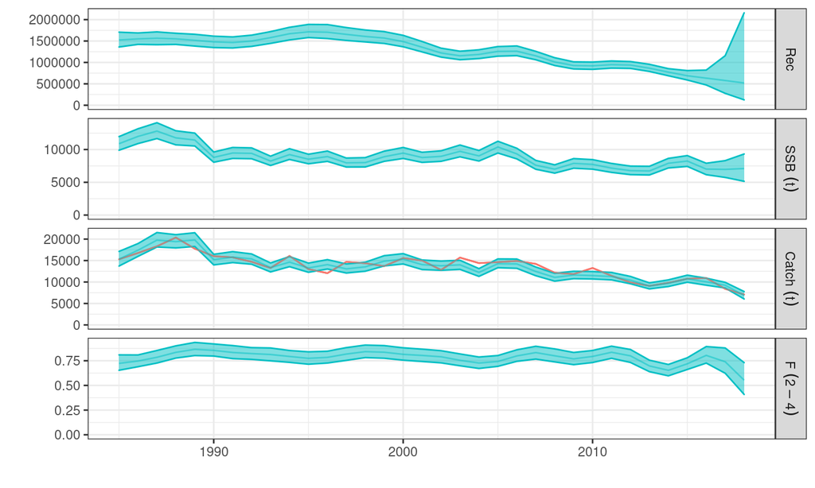

## Candidate run

### assuming Lorenzen M vector-harvest

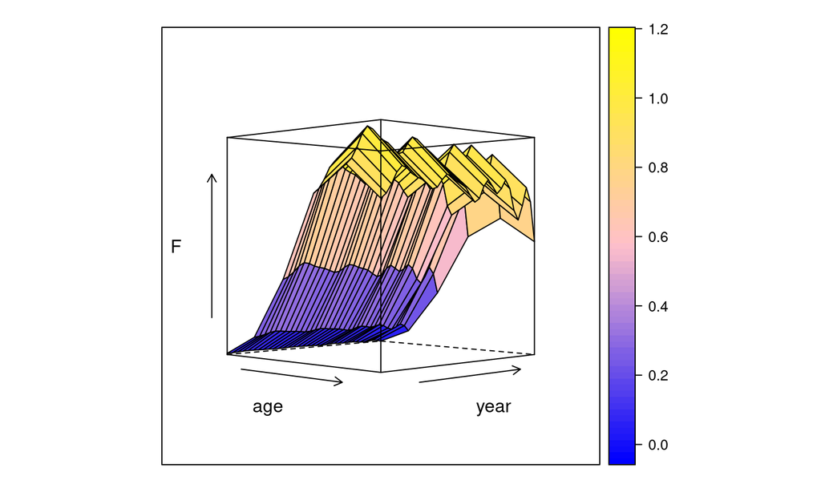

## Diagnostics

### candidate run assuming Lorenzen M vector

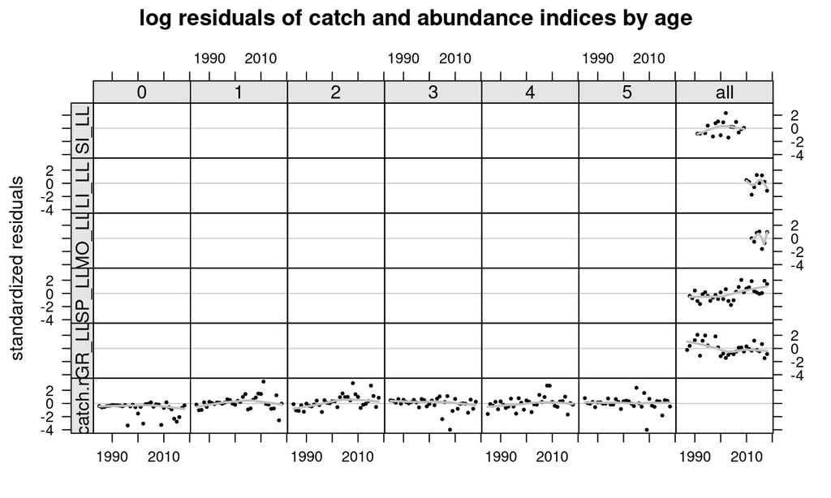

## Diagnostics

### candidate run assuming Lorenzen M vector

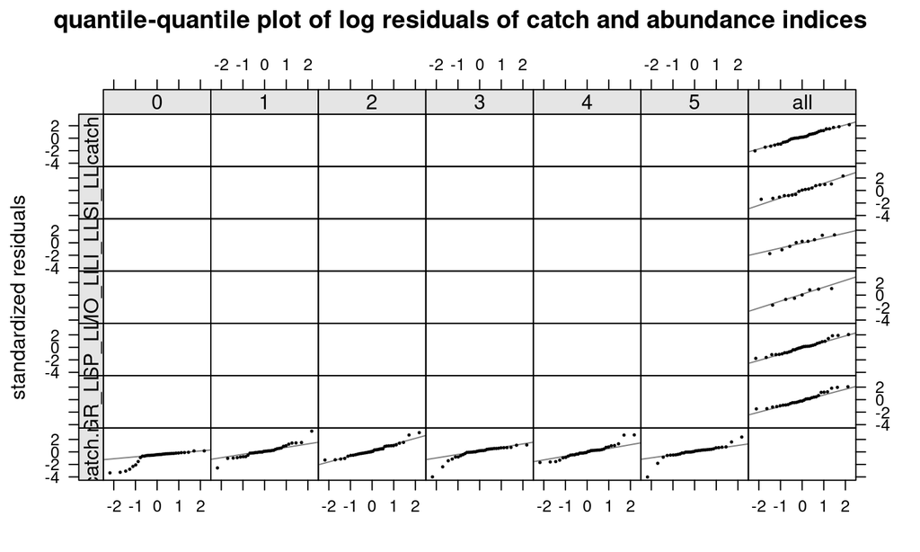

## Diagnostics

### candidate run assuming Lorenzen M vector

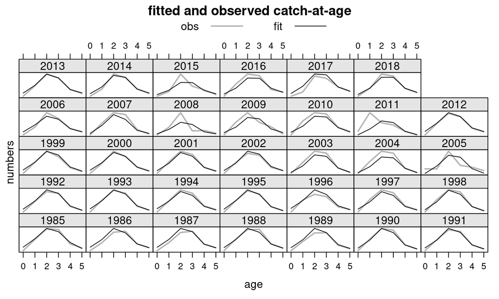

## Retrospective plot

### candidate run assuming Lorenzen M vector

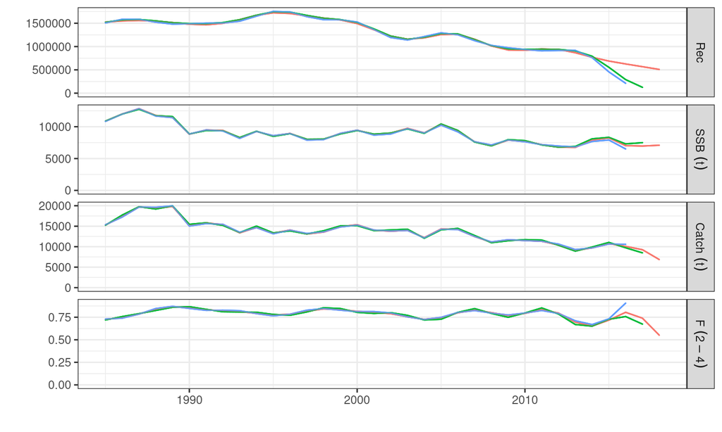

## Discard run

### assuming constant M

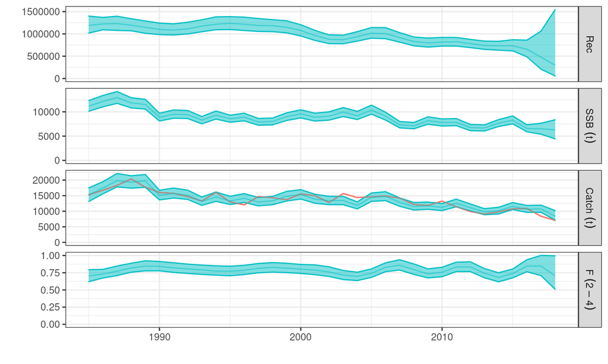

## Discard run

### assuming constant M - harvest

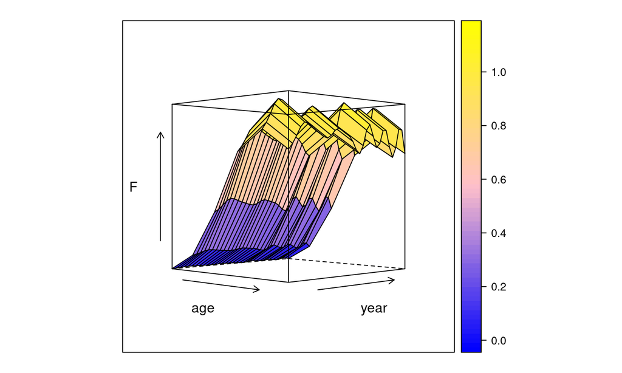

## Diagnostics

### Discards candidate run assuming constant M

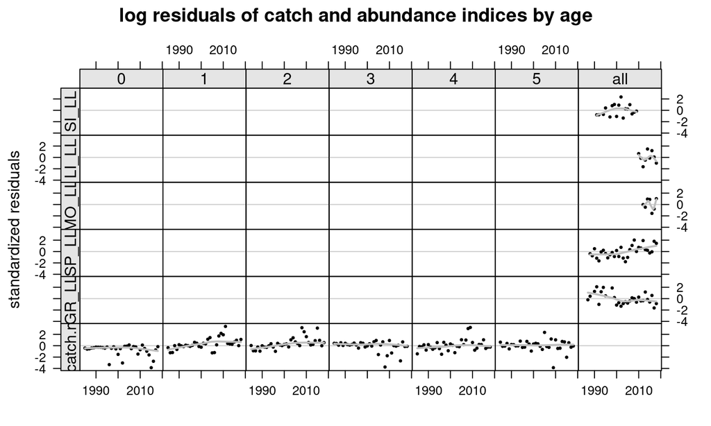

## Diagnostics

### Discards candidate run assuming constant M

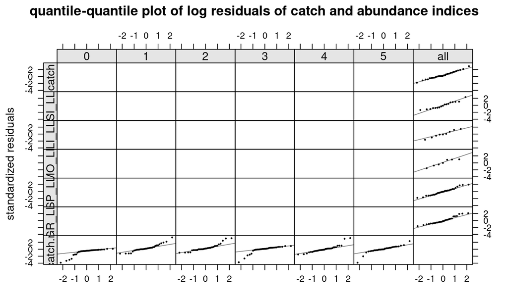

## Diagnostics

### Discards candidate run assuming constant M

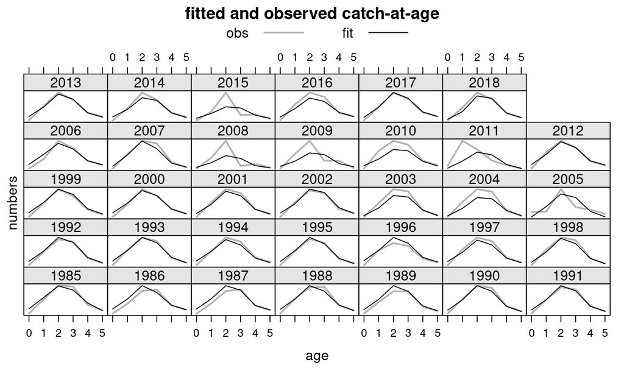

## Retrospective plot

### the discard run assuming constant M

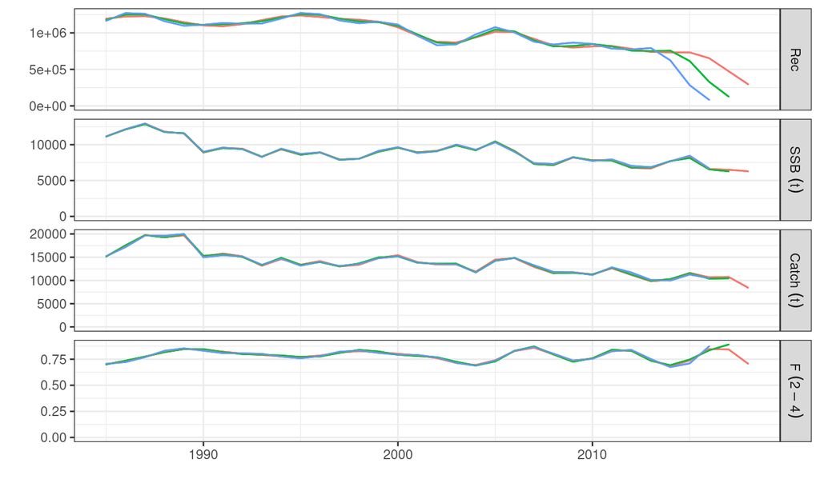

## Discard run

### assuming Lorenzen M vector

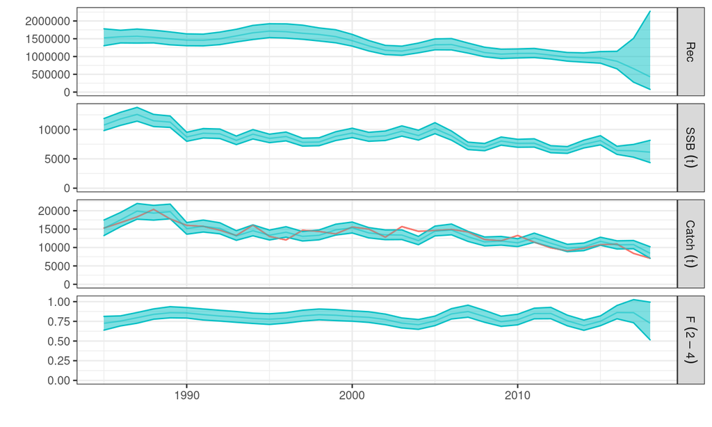

## Discard run

### assuming Lorenzen M vector - harvest

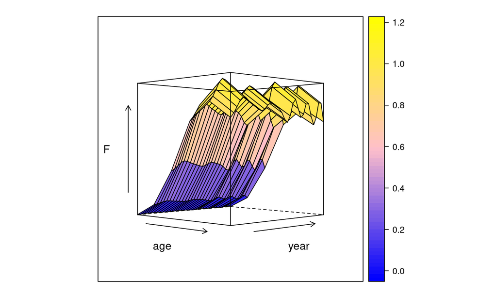

## Diagnostics

### Discards with Lorenzen M candidate Run

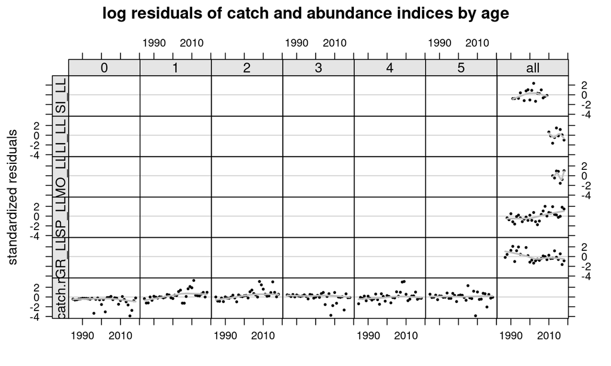

## Diagnostics

### Discards with Lorenzen M candidate Run

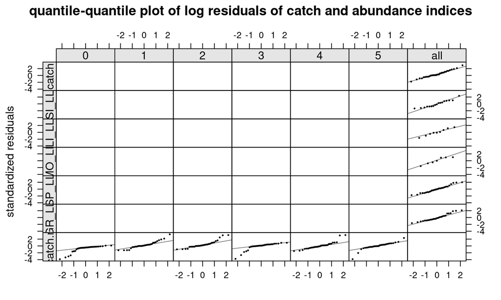

## Diagnostics

### Discards with Lorenzen M candidate Run

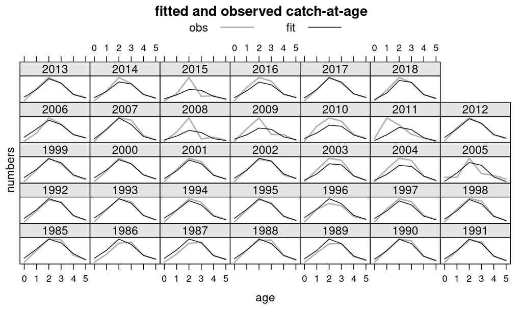

## Retrospective plot

### the discard run assuming Lorenzen M vector

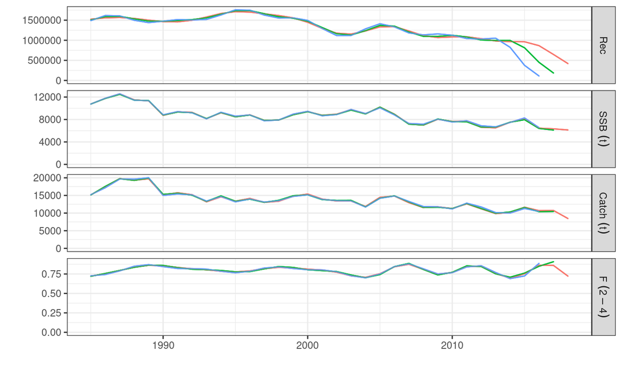

## All runs

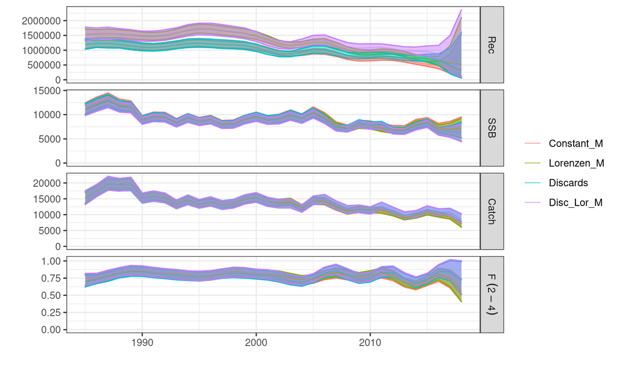

## Terminal values

| values | constantM | LorenzenM | Disc_constM | Disc_LorenM |
| --- | --- | --- | --- | --- |
| Fbar | 0.5384023 | 0.551435 | 0.7074047 | 0.7227007 |
| Recruitment | 376604.1 | 509087.5 | 296525.2 | 419811.8 |
| SSB | 7286.58 | 7088.482 | 6290.268 | 6137.171 |
| Catch | 6846.11 | 6866.544 | 8439.466 | 8462.589 |

## Reference Points

| value | constantM | LorenzenM | Disc_constM | Disc_LorenM |
| --- | --- | --- | --- | --- |
| FFmsy | 1.4041940 | 1.4381842 | 1.8449649 | 1.8848580 |
| FF0.1 | 2.6323894 | 2.6961095 | 3.4586859 | 3.5334720 |
| BBmsy | 0.5022871 | 0.5217658 | 0.4964845 | 0.5179383 |

## MCMC fit

## MCMC

### candidate run assuming constant M

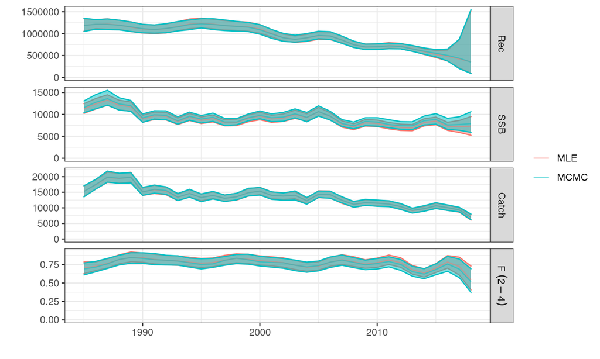

## References

Ernesto Jardim, Colin P. Millar, Iago Mosqueira, Finlay Scott, Giacomo Chato Osio, Marco Ferretti, Nekane Alzorriz, Alessandro Orio, What if stock assessment is as simple as a linear model? The a4a initiative, ICES Journal of Marine Science, Volume 72, Issue 1, January 2015, Pages 232–236, https://doi.org/10.1093/icesjms/fsu050

Fournier, D.A., Skaug, H.J., Ancheta, J., Ianelli, J., Magnusson, A., Maunder, M.N., Nielsen, A., and Sibert, J. 2012. AD Model Builder: using automatic differentiation for statistical inference of highly parameterized complex nonlinear models. Optim. Methods Softw. 27:233-249.

ICCAT, 2020. REPORT OF THE 2020 ICCAT INTERSESSIONAL MEETING OF THE SWORDFISH SPECIES GROUP. https://tinyurl.com/ycqfhjzl.

L. T. Kell, I. Mosqueira, P. Grosjean, J-M. Fromentin, D. Garcia, R. Hillary, E. Jardim, S. Mardle, M. A. Pastoors, J. J. Poos, F. Scott, R. D. Scott, FLR: an open-source framework for the evaluation and development of management strategies, ICES Journal of Marine Science, Volume 64, Issue 4, May 2007, Pages 640–646, https://doi.org/10.1093/icesjms/fsm012

R Core Team (2020). R: A language and environment for statistical computing. R Foundation for Statistical Computing, Vienna, Austria. URL http://www.R-project.org/

SCRS 2020/021. UPDATED STANDARDIZED SWORDFISH CATCH RATES FROM THE GREEK SURFACE LONGLINE FISHERIES OPERATING IN THE E. MEDITERRANEAN.

SCRS 2020/026. UPDATED CATCH RATES OF SWORDFISH *(XIPHIAS GLADIUS)* CAUGHT BY THE MOROCCAN LONGLINE FLEET IN THE MEDITERRANEAN SEA, 2012-2019

SCRS 2020/027. AN UPDATE OF THE SWORDFISH FISHERY IN THE LIGURIAN SEA (WESTERN MEDITERRANEAN) WITH A PRELIMINARY ATTEMPT TO STANDARDIZE THE MESOPELAGIC LONGLINE CPUEs.

## References

SCRS 2020/028. ESTIMATION OF UNDERSIZED MEDITERRANEAN SWORDFISH *(Xiphias gladius)* CATCHES BETWEEN 2008 – 2018 FOR THE LONGLINE MAIN FLEETS.

SCRS 2020/043. Standardized Catch Rates for the Mediterranean Swordfish (*Xiphias gladius* Linnaeus, 1758) from the Spanish Longline Fishery. 1988-2018.

Tserpes, G., Peristeraki, P., Di Natale, A., Mangano, A. 2011. Analysis of swordfish (Xiphias gladius) catch rates in the central-eastern Mediterranean. Collect. Vol. Sci. Pap. ICCAT, 66(4): 1495-1505.

Wood, S.N. (2003) Thin-plate regression splines. Journal of the Royal Statistical Society (B) 65(1):95-114.